# Clustering

Group 1

2023-07-11

```r
suppressPackageStartupMessages({
  library(GenomicRanges)
  library(epiwraps)
  library(ggplot2)
  library(rGREAT)
  library(AnnotationHub)
  library(MotifDb)
  #library(memes)
  library(universalmotif)
  library(ensembldb)
  library(Rsamtools)
  library(motifmatchr)
  library(sechm)
  library(BiocParallel)
  library(chromVAR) # for motif accessibility estimation
  library(SummarizedExperiment) # data structure
  library(limma) # for statistical analysis
  library(bsseq)
  library(edgeR)
  library(DMRcate)
  library(rtracklayer)
  library(pheatmap)
  library(viridis)
  library(data.table)
  library(BRGenomics)
  library(BioMartGOGeneSets) # for GO analysis
  library(BSgenome.Rnorvegicus.UCSC.rn7)
})
```

```
## See system.file("LICENSE", package="MotifDb") for use restrictions.
```

# Clustering

```r
# new names
# Rename peaks
new_names_3_1 <- c("FS30 GR", "BLAM GR", "BLPM GR")
new_names_3_2 <- c("FS30 MR", "BLAM MR", "BLPM MR")
# prepare regions and tracks
tracks_1 <- list.files(path = "D:\\bioinformatics_final_project\\Laura\\Bw", pattern="GR.bw$", full = TRUE)
region_files_1 <- list.files(path = "D:\\bioinformatics_final_project\\Laura\\NarrowPeaks",full=TRUE, pattern = "GR_peaks.narrowPeak")
peaks_1 <- lapply(region_files_1, FUN=rtracklayer::import)
regions_1 <- reduce(unlist(GRangesList(peaks_1)))
tracks_2 <- list.files(path = "D:\\bioinformatics_final_project\\Laura\\Bw", pattern="MR.bw$", full = TRUE)
region_files_2 <- list.files(path = "D:\\bioinformatics_final_project\\Laura\\NarrowPeaks",full=TRUE, pattern = "MR_peaks.narrowPeak")
peaks_2 <- lapply(region_files_2, FUN=rtracklayer::import)
regions_2 <- reduce(unlist(GRangesList(peaks_2)))
# build matrix and plot
ml_1 <- signal2Matrix(tracks_1, regions_1, extend=2000)
```

```
## Reading D:\bioinformatics_final_project\Laura\Bw/SRX5371942.GSM3602775.Late_afternoon_baseline_GR.bw
```

```
## Reading D:\bioinformatics_final_project\Laura\Bw/SRX5371944.GSM3602751.Early_morning_baseline_GR.bw
```

```
## Reading D:\bioinformatics_final_project\Laura\Bw/SRX5371947.GSM3602754.Acute_stress_GR.bw
```

```
## Reading D:\bioinformatics_final_project\Laura\Bw/SRX5371950.GSM3602757.Late_afternoon_baseline_GR.bw
```

```
## Reading D:\bioinformatics_final_project\Laura\Bw/SRX5371953.GSM3602760.Early_morning_baseline_GR.bw
```

```
## Reading D:\bioinformatics_final_project\Laura\Bw/SRX5371956.GSM3602763.Acute_stress_GR.bw
```

```
## Reading D:\bioinformatics_final_project\Laura\Bw/SRX5371959.GSM3602766.Late_afternoon_baseline_GR.bw
```

```
## Reading D:\bioinformatics_final_project\Laura\Bw/SRX5371962.GSM3602769.Early_morning_baseline_GR.bw
```

```
## Reading D:\bioinformatics_final_project\Laura\Bw/SRX5371965.GSM3602772.Acute_stress_GR.bw
```

```
## Reading D:\bioinformatics_final_project\Laura\Bw/SRX5371969.GSM3602778.Early_morning_baseline_GR.bw
```

```
## Reading D:\bioinformatics_final_project\Laura\Bw/SRX5371972.GSM3602781.Acute_stress_GR.bw
```

```
## Reading D:\bioinformatics_final_project\Laura\Bw/SRX5371975.GSM3602784.Late_afternoon_baseline_GR.bw
```

```r
nf_1 <- rep(1, length(ml_1)) # see differential analysis file for the choice of the normalization factor
mln_1 <- rescaleSignalMatrices(ml_1, nf_1)
names(mln_1) <- c("GR_peaks_BLPM_A", "GR_peaks_BLAM_A", "GR_peaks_FS30_A", "GR_peaks_BLPM_B", "GR_peaks_BLAM_B", "GR_peaks_FS30_B", "GR_peaks_BLPM_C", "GR_peaks_BLAM_C", "GR_peaks_FS30_C", "GR_peaks_BLAM_D", "GR_peaks_FS30_D", "GR_peaks_BLPM_D")
smMerged_1 <- list(
  BLAM_GR = mergeSignalMatrices(mln_1[c("GR_peaks_BLAM_A","GR_peaks_BLAM_B", "GR_peaks_BLAM_C", "GR_peaks_BLAM_D")]),
  BLPM_GR = mergeSignalMatrices(mln_1[c("GR_peaks_BLPM_A","GR_peaks_BLPM_B", "GR_peaks_BLPM_C", "GR_peaks_BLPM_D")]),
  FS30_GR = mergeSignalMatrices(mln_1[c("GR_peaks_FS30_A","GR_peaks_FS30_B", "GR_peaks_FS30_C", "GR_peaks_FS30_D")]))
ml_2 <- signal2Matrix(tracks_2, regions_2, extend=2000)
```

```
## Reading D:\bioinformatics_final_project\Laura\Bw/SRX5371943.GSM3602776.Late_afternoon_baseline_MR.bw
```

```
## Reading D:\bioinformatics_final_project\Laura\Bw/SRX5371945.GSM3602752.Early_morning_baseline_MR.bw
```

```
## Reading D:\bioinformatics_final_project\Laura\Bw/SRX5371948.GSM3602755.Acute_stress_MR.bw
```

```
## Reading D:\bioinformatics_final_project\Laura\Bw/SRX5371951.GSM3602758.Late_afternoon_baseline_MR.bw
```

```
## Reading D:\bioinformatics_final_project\Laura\Bw/SRX5371954.GSM3602761.Early_morning_baseline_MR.bw
```

```
## Reading D:\bioinformatics_final_project\Laura\Bw/SRX5371957.GSM3602764.Acute_stress_MR.bw
```

```
## Reading D:\bioinformatics_final_project\Laura\Bw/SRX5371960.GSM3602767.Late_afternoon_baseline_MR.bw
```

```
## Reading D:\bioinformatics_final_project\Laura\Bw/SRX5371963.GSM3602770.Early_morning_baseline_MR.bw
```

```
## Reading D:\bioinformatics_final_project\Laura\Bw/SRX5371966.GSM3602773.Acute_stress_MR.bw
```

```
## Reading D:\bioinformatics_final_project\Laura\Bw/SRX5371970.GSM3602779.Early_morning_baseline_MR.bw
```

```
## Reading D:\bioinformatics_final_project\Laura\Bw/SRX5371973.GSM3602782.Acute_stress_MR.bw
```

```
## Reading D:\bioinformatics_final_project\Laura\Bw/SRX5371976.GSM3602785.Late_afternoon_baseline_MR.bw
```

```
## 'magick' package is suggested to install to give better rasterization.
##
## Set `ht_opt$message = FALSE` to turn off this message.
```

[output not shown]

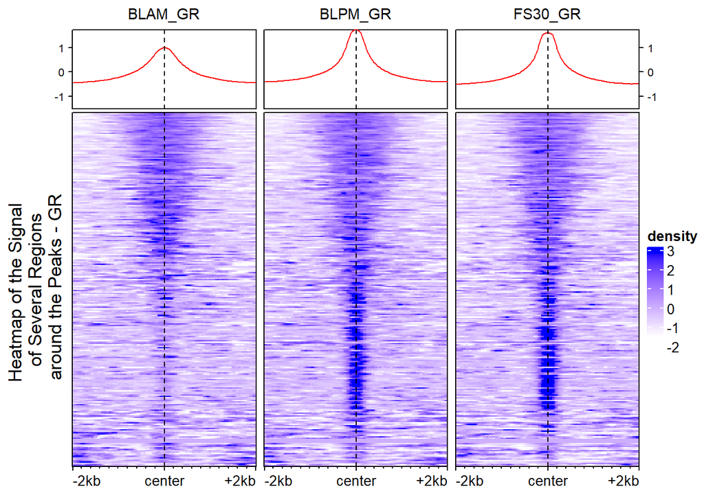

```r
nf_2 <- rep(1, length(ml_2)) # see differential analysis file for the choice of the normalization factor
mln_2 <- rescaleSignalMatrices(ml_2, nf_2)
names(mln_2) <- c("MR_peaks_BLPM_A", "MR_peaks_BLAM_A", "MR_peaks_FS30_A", "MR_peaks_BLPM_B", "MR_peaks_BLAM_B", "MR_peaks_FS30_B", "MR_peaks_BLPM_C", "MR_peaks_BLAM_C", "MR_peaks_FS30_C", "MR_peaks_BLAM_D", "MR_peaks_FS30_D", "MR_peaks_BLPM_D")
smMerged_2 <- list(
  BLAM_MR = mergeSignalMatrices(mln_2[c("MR_peaks_BLAM_A","MR_peaks_BLAM_B", "MR_peaks_BLAM_C", "MR_peaks_BLAM_D")]),
  BLPM_MR = mergeSignalMatrices(mln_2[c("MR_peaks_BLPM_A","MR_peaks_BLPM_B", "MR_peaks_BLPM_C", "MR_peaks_BLPM_D")]),
  FS30_MR = mergeSignalMatrices(mln_2[c("MR_peaks_FS30_A","MR_peaks_FS30_B", "MR_peaks_FS30_C", "MR_peaks_FS30_D")]))
set.seed(123)
plotEnrichedHeatmaps(smMerged_1,colors = c("white", "blue"), row_title = "Heatmap of the Signal \n of Several Regions \n around the Peaks - GR", scale_rows = "global")
```

[output not shown]

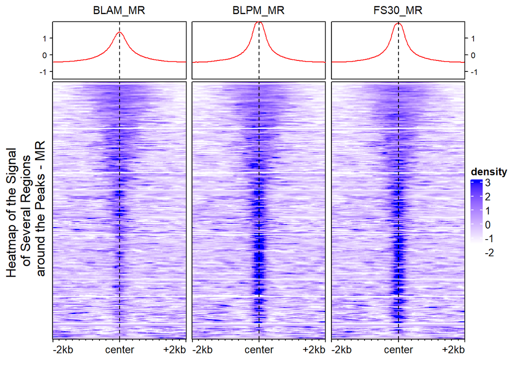

```r
plotEnrichedHeatmaps(smMerged_2,colors = c("white", "blue"), row_title = "Heatmap of the Signal \n of Several Regions \n around the Peaks - MR", scale_rows = "global")
```

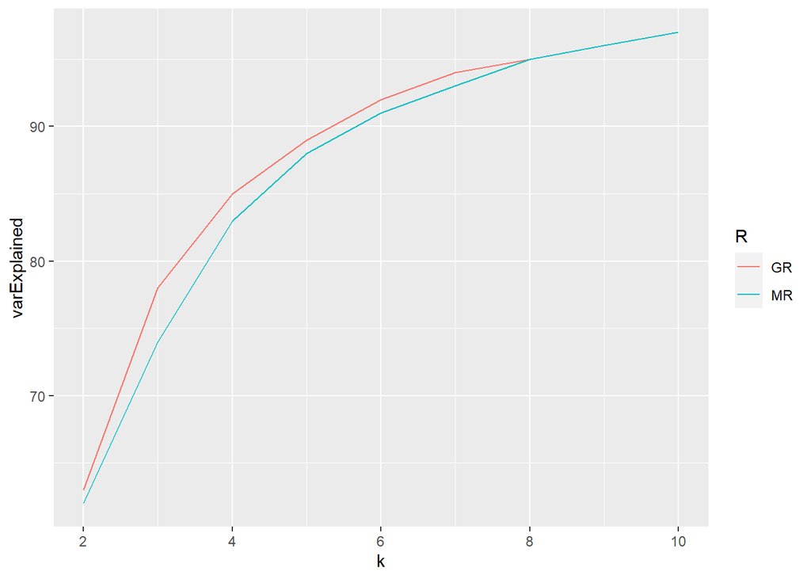

```r
# Choosing a meaningful number of clusters
multi_cl_1 <- clusterSignalMatrices(smMerged_1, k=2:10, scaleRows = TRUE)
multi_cl_2 <- clusterSignalMatrices(smMerged_2, k=2:10, scaleRows = TRUE)
cl1 <- multi_cl_1$varExplained
cl1$R <- c("GR","GR","GR","GR","GR","GR","GR","GR","GR")
cl2 <- multi_cl_2$varExplained
cl2$R <- c("MR","MR","MR","MR","MR","MR","MR","MR","MR")
cltot <- rbind(cl1, cl2)
ggplot(cltot, aes(k, varExplained, color = R)) + geom_line()
```

```r
# Clustering
set.seed(123)  # to ensure that it gives the same results everytime
cl_1 <- clusterSignalMatrices(smMerged_1, k=6, scaleRows = TRUE) # choose k according to previous plot
```

```
##   ~92% of the variance explained by clusters
```

```r
table(cl_1)
```

```
## cl_1
##    1    2    3    4    5    6
##  710  964 2399 2119 1053  975
```

```r
head(cl_1)
```

```
## [1] 1 2 3 3 3 5
## Levels: 1 2 3 4 5 6
```

```r
length(cl_1)
```

```
## [1] 8220
```

```r
length(regions_1)
```

```
## [1] 8220
```

```r
regions_1$cluster <- cl_1
cl_2 <- clusterSignalMatrices(smMerged_2, k=6, scaleRows = TRUE) # choose k according to previous plot
```

```
##   ~91% of the variance explained by clusters
```

```r
table(cl_2)
```

```
## cl_2
##    1    2    3    4    5    6
## 1770 1352 1278 3185 1120 1784
```

```r
head(cl_2)
```

```
## [1] 1 5 2 3 1 4
## Levels: 1 2 3 4 5 6
```

```r
length(cl_2)
```

```
## [1] 10489
```

```r
length(regions_2)
```

```
## [1] 10489
```

[output not shown]

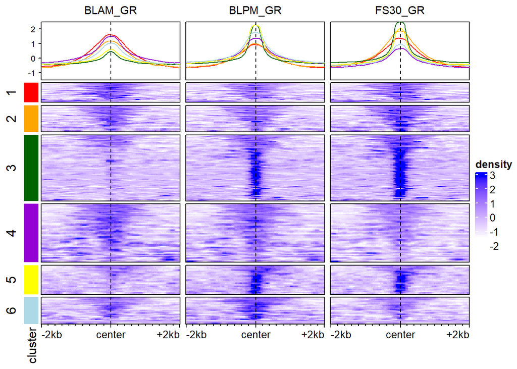

```r
regions_2$cluster <- cl_2
# Plot clusters with colors
mycolors <- c("1"="red", "2"="orange", "3"="darkgreen", "4"="darkviolet", "5"="yellow", "6" = "lightblue") #, "7" = "darkblue")
plotEnrichedHeatmaps(smMerged_1, row_split=cl_1, mean_color=mycolors,colors = c("white", "blue"), scale_rows = "global")
```

[output not shown]

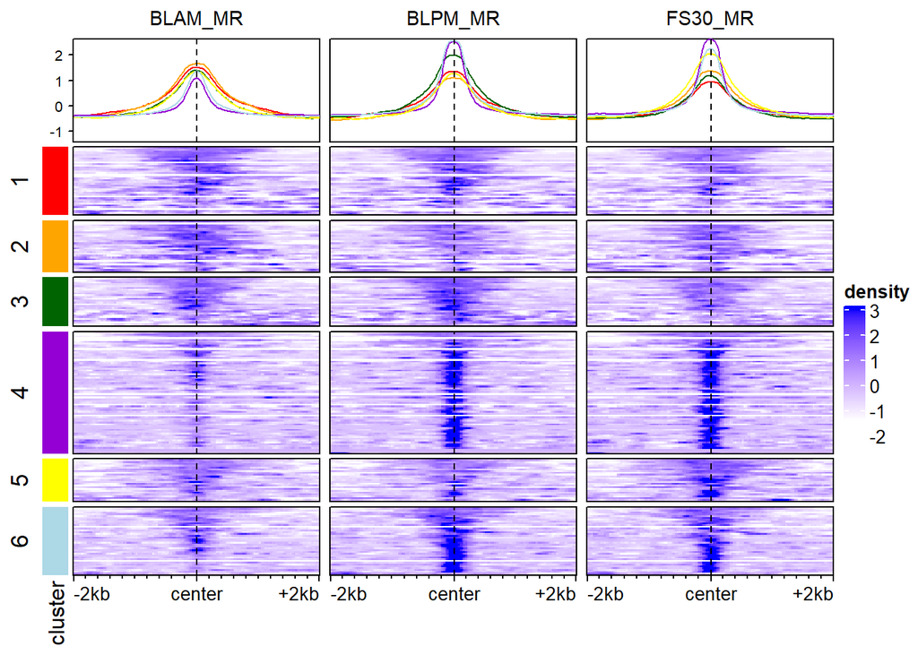

```r
plotEnrichedHeatmaps(smMerged_2, row_split=cl_2, mean_color=mycolors,colors = c("white", "blue"), scale_rows = "global")
```

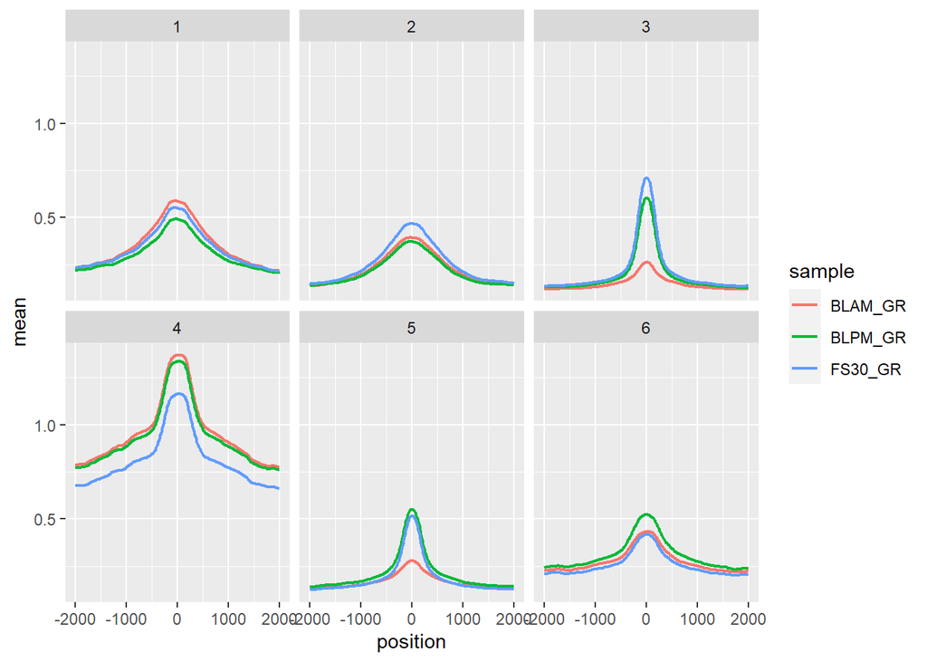

```r
# Plotting averages
d <- meltSignals(smMerged_1, splitBy=cl_1)
ggplot(d, aes(position, mean, colour=sample)) + geom_line(linewidth = 0.8) + facet_wrap(~split)
```

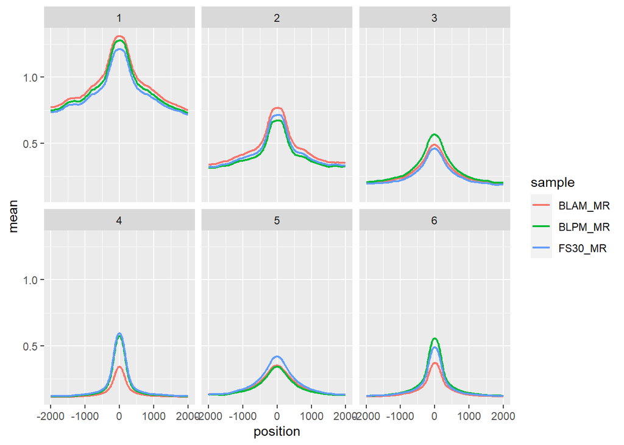

```r
d <- meltSignals(smMerged_2, splitBy=cl_2)
ggplot(d, aes(position, mean, colour=sample)) + geom_line(linewidth = 0.8) + facet_wrap(~split)
```

To identify regions in the genome that are similar to each other, we decided to use the clustering method. Clustering allows to build groups of data based on their similarity. This is useful for various reasons. The first reason is that we can observe differences in the signal under the three conditions with the help of a heatmap, while these would look more similar without any clustering. Secondly, as the members of one group have similar characteristics, it will be easier to identify significant effects with appropriate analyses. For example, doing a GO analysis on the different clusters will allow to find what is most likely the function of these genes. As genes in the genomes perform a wide variety of functions, performing a GO analysis on clusters is more likely going to give positive results.

We decided to perform a separated clustering on GR and MR data to have the best clusters for each receptor. For each receptor, we collected the peaks and we used the input coverage of each condition as tracks to compute the signal around the peak regions. We firstly computed several clustering options (different number of clusters), and with the help of a plot showing the explained variance as a function of the number of clusters we determined the number of clusters we wanted to use with the “elbow method”, i.e. we chose the number of clusters after which further increasing would not lead to a large difference in terms of the explained variance. The number of clusters we chose in the end is six, but the choice remains subjective.

From the heatmaps, for both GR and MR, we can see differences across conditions. Without clusters we can already see that globally there is more signal in the FS30 condition and in the BLPM condition, compared to the BLAM control. However, with the help of clustering, we can actually see that the signal in some regions stays more similar across conditions, while in some clusters we can see more signal in the FS30 condition and/ or in the BLPM condition, and we can evence see differences between these conditions, while it seems there is more signal in the BLAM condition, probably suggesting that the functions of those regions are suppressed upon stress and/ or in the late afternoon, when the level of glucocorticoids is higher. Rattus norvegicus is a nocturnal animal (Cuesta et al., 2009) and as a nocturnal animal, it has higher glucocorticoid release late in the afternoon, just before its active phase starts (Dickmeis, 2009). Similarly, glucocorticoid release is known to be a reaction to stress (Whirledge & Cidlowski, 2010). GO analysis results will help to see whether the functions of the regions in those specific clusters are consistent with previous findings.